# Data Mining Homework(NFL Data)

```r
summary(nfl_numeric[["ScoreDiff"]])
```

```
##    Min. 1st Qu.  Median    Mean 3rd Qu.    Max.    NA's
## -59.000  -7.000   0.000  -1.187   4.000  59.000   24988
```

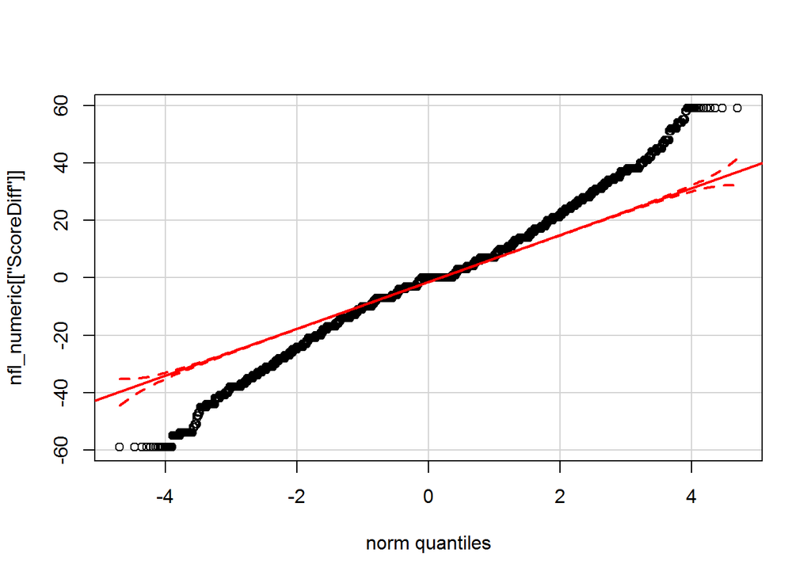

```r
qqPlot(nfl_numeric[["ScoreDiff"]])
```

```r
plyr::count(is.na(nfl_numeric[["HomeTimeouts_Remaining_Post"]]))
```

```
##       x   freq
## 1 FALSE 407688
```

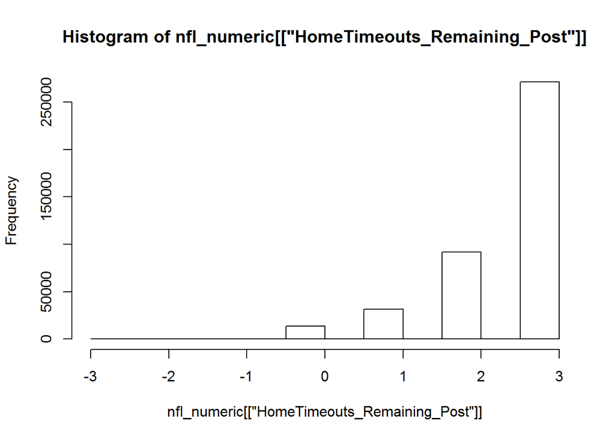

```r
hist(nfl_numeric[["HomeTimeouts_Remaining_Post"]])
```

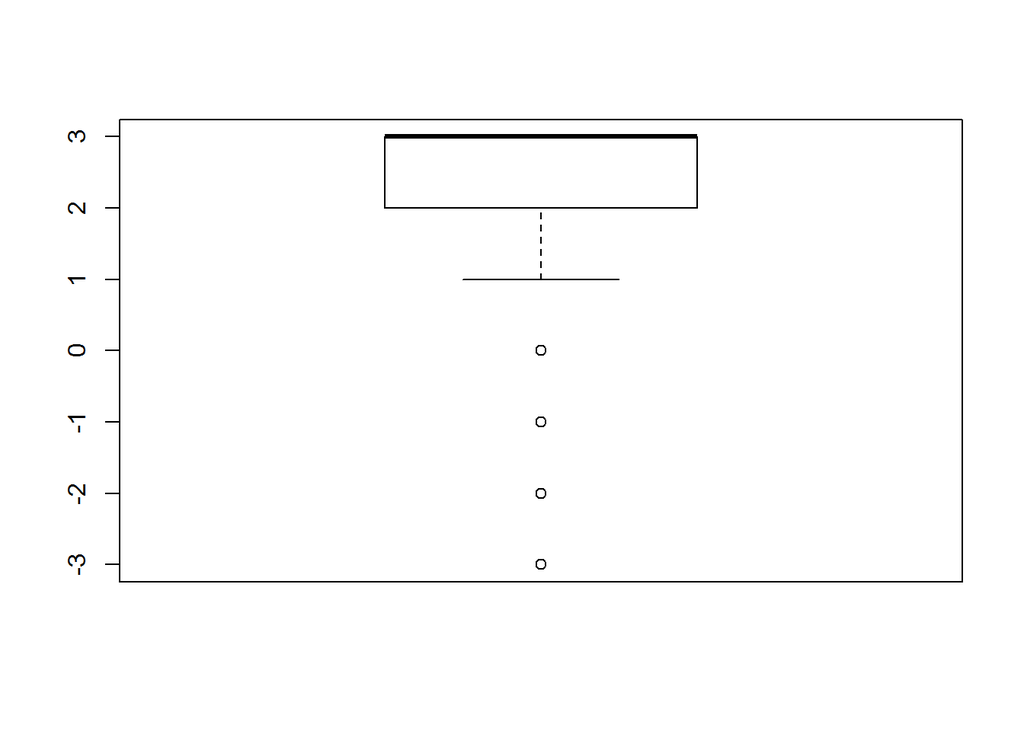

```r
boxplot(nfl_numeric[["HomeTimeouts_Remaining_Post"]])
```

```r
summary(nfl_numeric[["HomeTimeouts_Remaining_Post"]])
```

```
##    Min. 1st Qu.  Median    Mean 3rd Qu.    Max.
##   -3.00    2.00    3.00    2.52    3.00    3.00
```

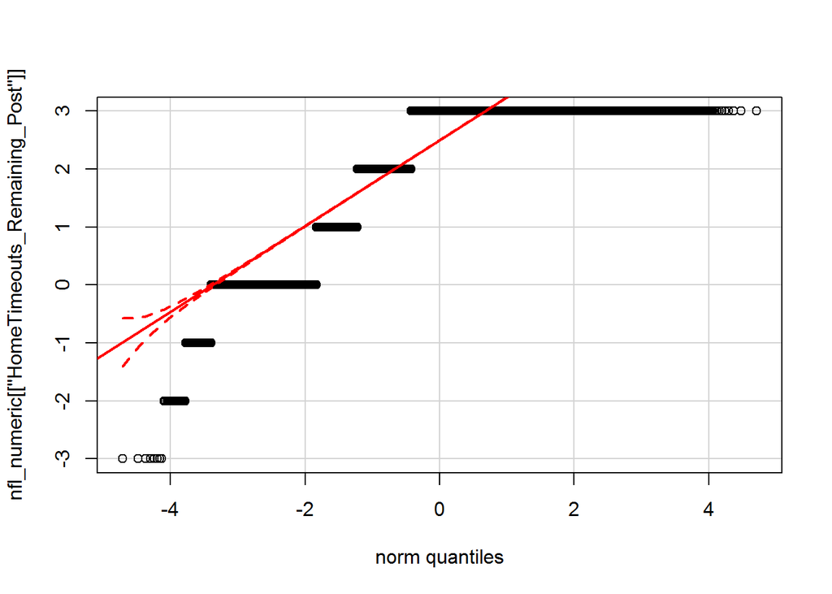

```r
qqPlot(nfl_numeric[["HomeTimeouts_Remaining_Post"]])
```

```r
plyr::count(is.na(nfl_numeric[["AwayTimeouts_Remaining_Post"]]))
```

```
##       x   freq
## 1 FALSE 407688
```

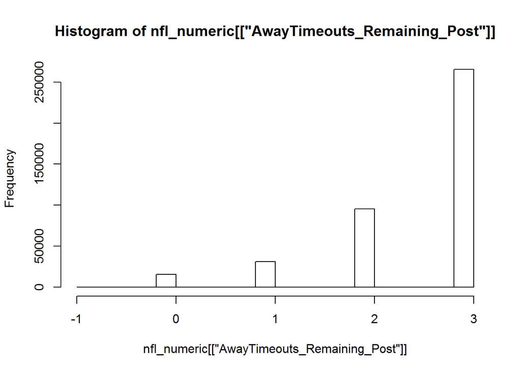

```r
hist(nfl_numeric[["AwayTimeouts_Remaining_Post"]])
```

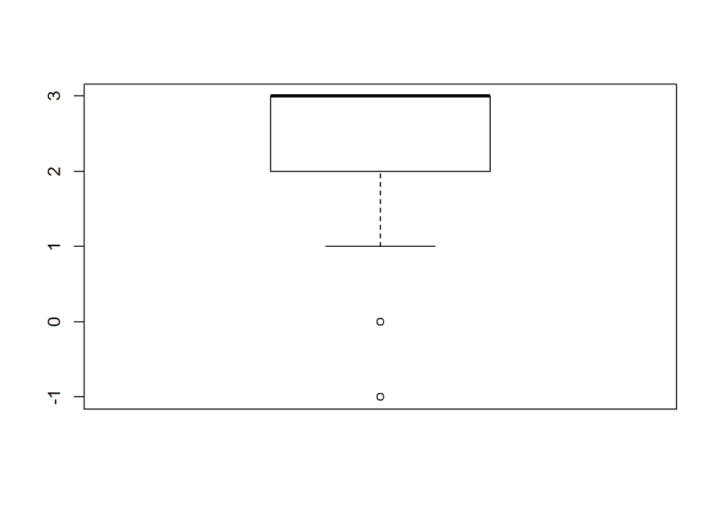

```r
boxplot(nfl_numeric[["AwayTimeouts_Remaining_Post"]])
```

```r
summary(nfl_numeric[["AwayTimeouts_Remaining_Post"]])
```

```
##    Min. 1st Qu.  Median    Mean 3rd Qu.    Max.
##  -1.000   2.000   3.000   2.496   3.000   3.000
```

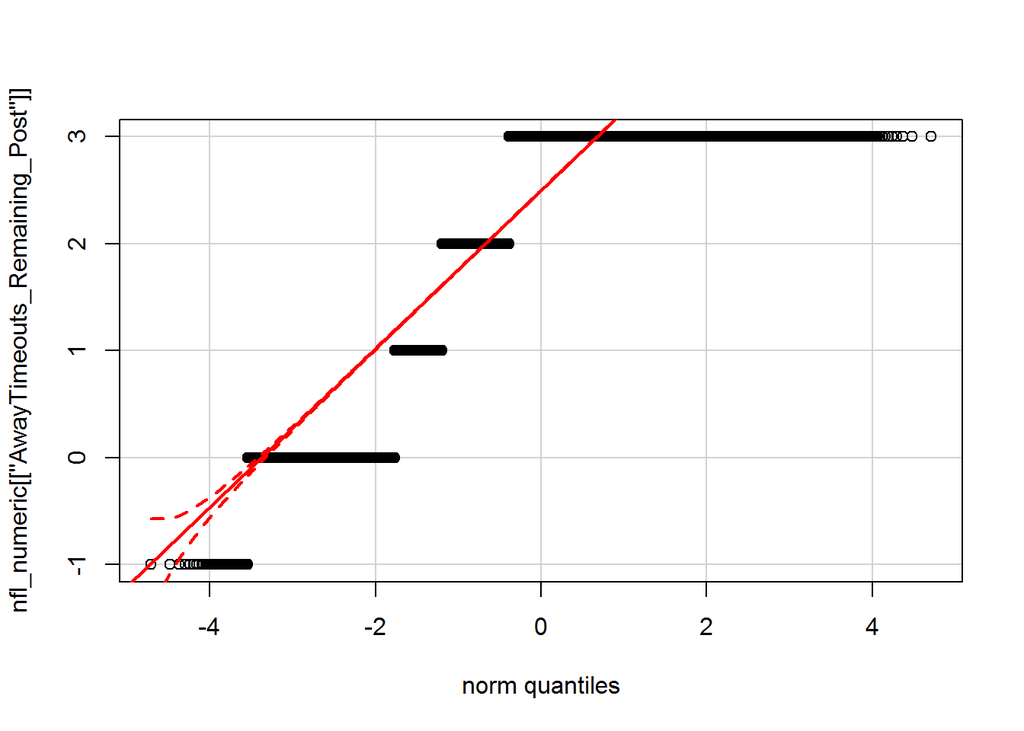

```r
qqPlot(nfl_numeric[["AwayTimeouts_Remaining_Post"]])
```

```r
plyr::count(is.na(nfl_numeric[["HomeTimeouts_Remaining_Pre"]]))
```

```
##       x   freq
## 1 FALSE 407688
```

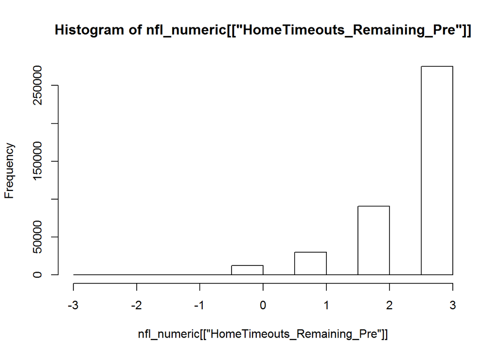

```r
hist(nfl_numeric[["HomeTimeouts_Remaining_Pre"]])
```

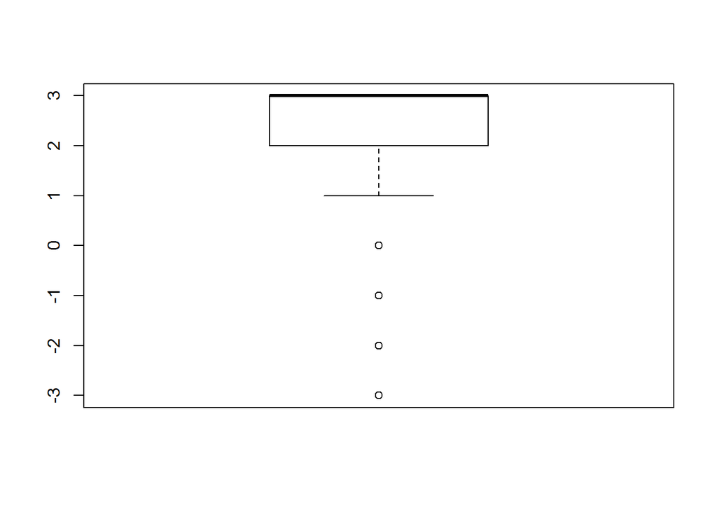

```r
boxplot(nfl_numeric[["HomeTimeouts_Remaining_Pre"]])
```

```r
summary(nfl_numeric[["HomeTimeouts_Remaining_Pre"]])
```

```
##    Min. 1st Qu.  Median    Mean 3rd Qu.    Max.
##   -3.00    2.00    3.00    2.54    3.00    3.00
```

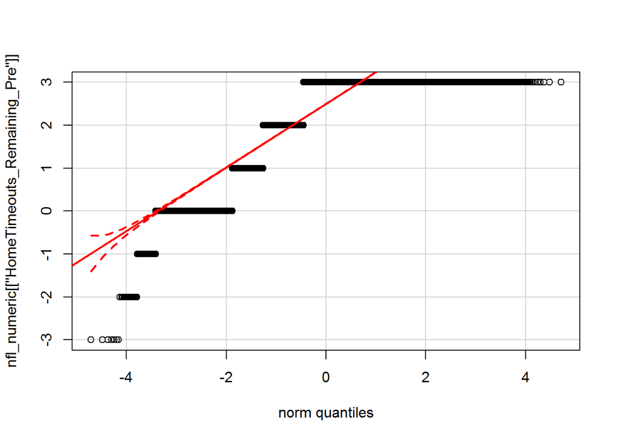

```r
qqPlot(nfl_numeric[["HomeTimeouts_Remaining_Pre"]])
```

```r
plyr::count(is.na(nfl_numeric[["AwayTimeouts_Remaining_Pre"]]))
```

```
##       x   freq
## 1 FALSE 407688
```

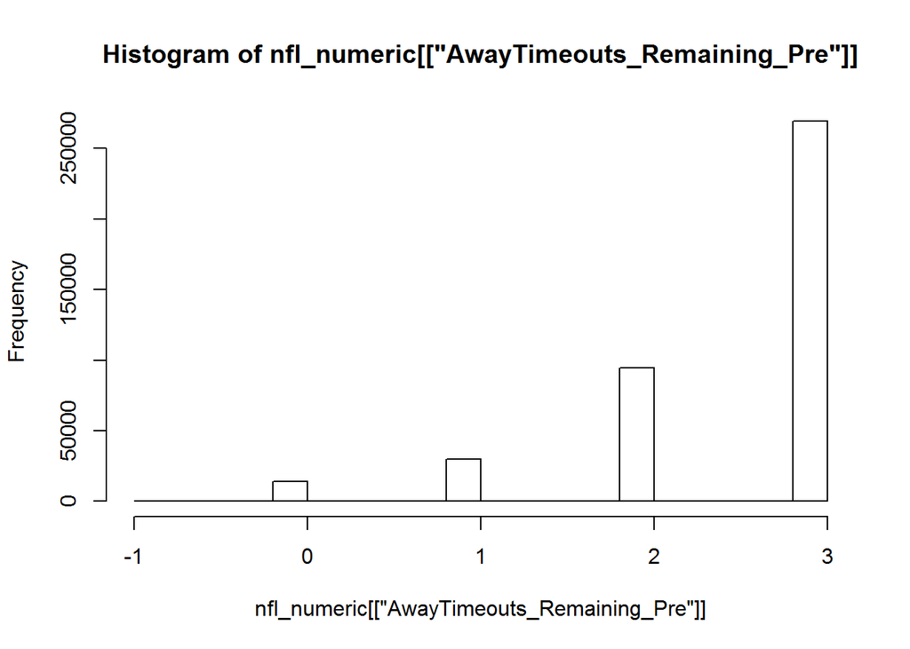

```r
hist(nfl_numeric[["AwayTimeouts_Remaining_Pre"]])
```

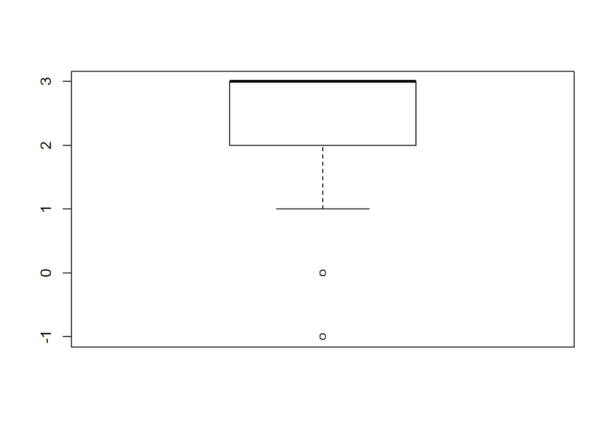

```r
boxplot(nfl_numeric[["AwayTimeouts_Remaining_Pre"]])
```

```r
summary(nfl_numeric[["AwayTimeouts_Remaining_Pre"]])
```

```
##    Min. 1st Qu.  Median    Mean 3rd Qu.    Max.
##  -1.000   2.000   3.000   2.517   3.000   3.000
```

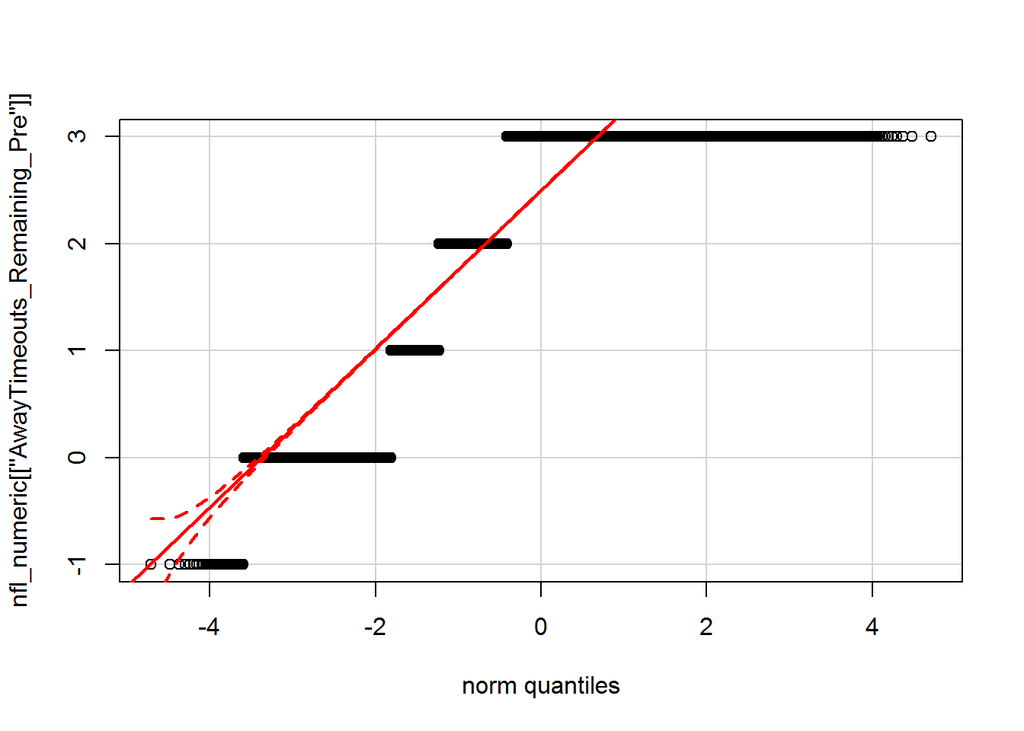

```r
qqPlot(nfl_numeric[["AwayTimeouts_Remaining_Pre"]])
```

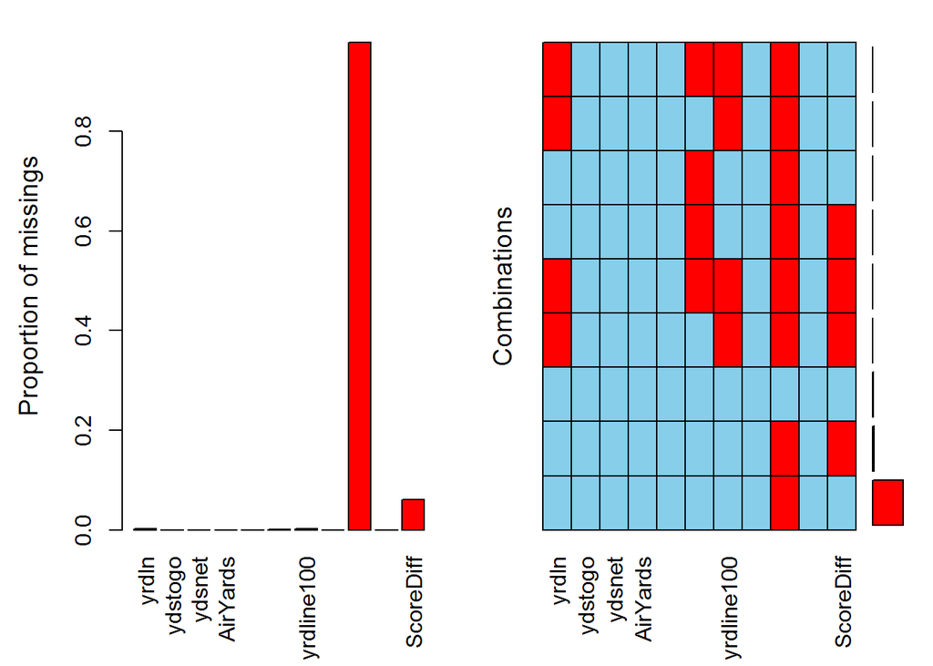

```r
library(lattice)
library(mice)
library(VIM)
aggr(nfl_numeric[,1:11], prop = TRUE, number = TRUE, combined = FALSE)
```

```r
md.pattern(nfl_numeric[,1:11])
```

```
##        ydstogo ydsnet AirYards YardsAfterCatch Yards.Gained Penalty.Yards
##   8948       1      1        1               1            1             1
## 373651       1      1        1               1            1             1
##     74       1      1        1               1            1             1
##  24013       1      1        1               1            1             1
##     26       1      1        1               1            1             1
##    162       1      1        1               1            1             1
##      1       1      1        1               1            1             1
##    606       1      1        1               1            1             1
##    207       1      1        1               1            1             1
##              0      0        0               0            0             0
##        PlayTimeDiff yrdln yrdline100 ScoreDiff FieldGoalDistance
##   8948            1     1          1         1                 1      0
## 373651            1     1          1         1                 0      1
##     74            0     1          1         1                 0      2
##  24013            1     1          1         0                 0      2
##     26            1     0          0         1                 0      3
##    162            0     1          1         0                 0      3
##      1            0     0          0         1                 0      4
##    606            1     0          0         0                 0      4
##    207            0     0          0         0                 0      5
##                 444   840        840     24988            398740 425852
```

There are several theories for NA values.

Most NA values stands for things that never truly exist. For example, as for the attribute “FieldGoalDistance”, the attribute makes no sense if there were no goals at all.

Besides, equipment malfunction, data error or refusing of the person interviewed to provide data, things that that can also cause NA in original data set.

Dealing with missing value: omit missing value. Take the “yrdln” as an example. It’s obvious that the visualization of data does not change after omitting NA values.

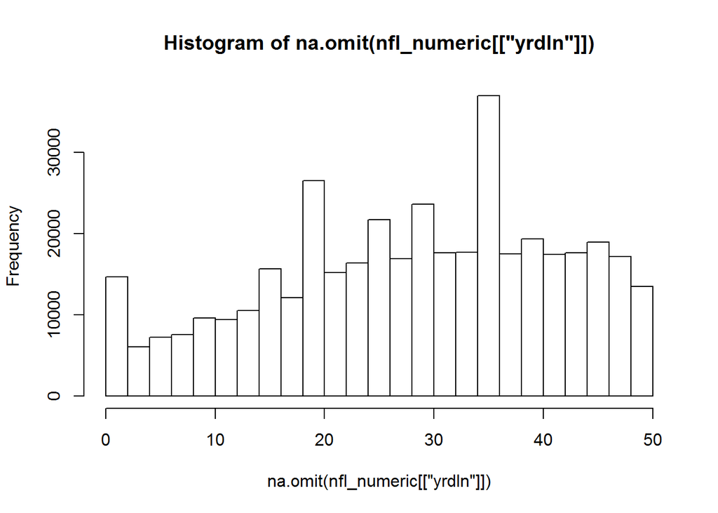

```r
hist(na.omit(nfl_numeric[["yrdln"]]))
```

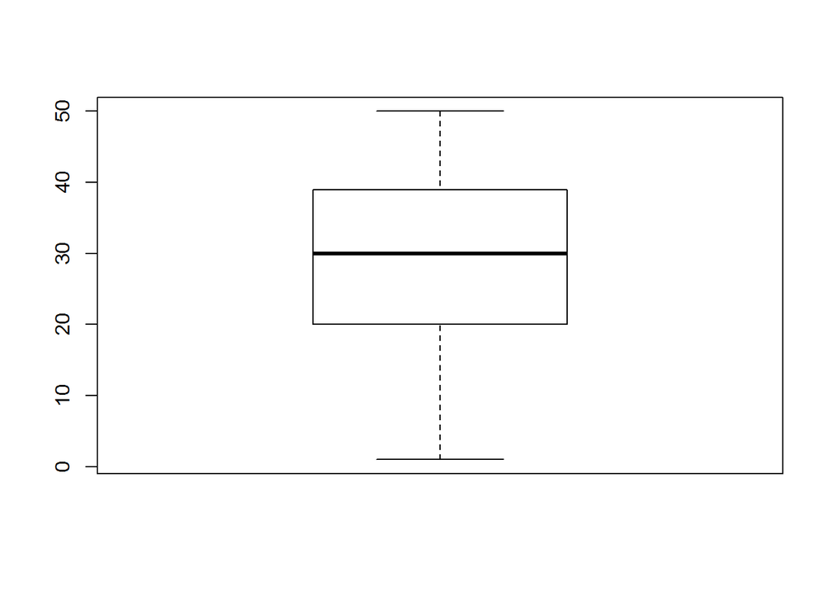

```r
boxplot(na.omit(nfl_numeric[["yrdln"]]))
```

```r
summary(na.omit(nfl_numeric[["yrdln"]]))
```

```
##    Min. 1st Qu.  Median    Mean 3rd Qu.    Max.
##    1.00   20.00   30.00   28.49   39.00   50.00
```

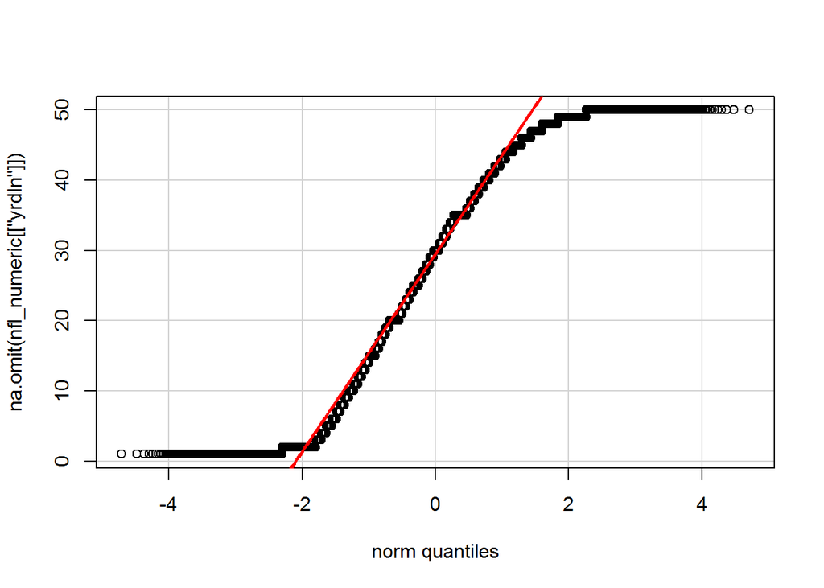

```r
qqPlot(na.omit(nfl_numeric[["yrdln"]]))
```

Dealing with missing value: filling NA with value of largest frequency. yrdln

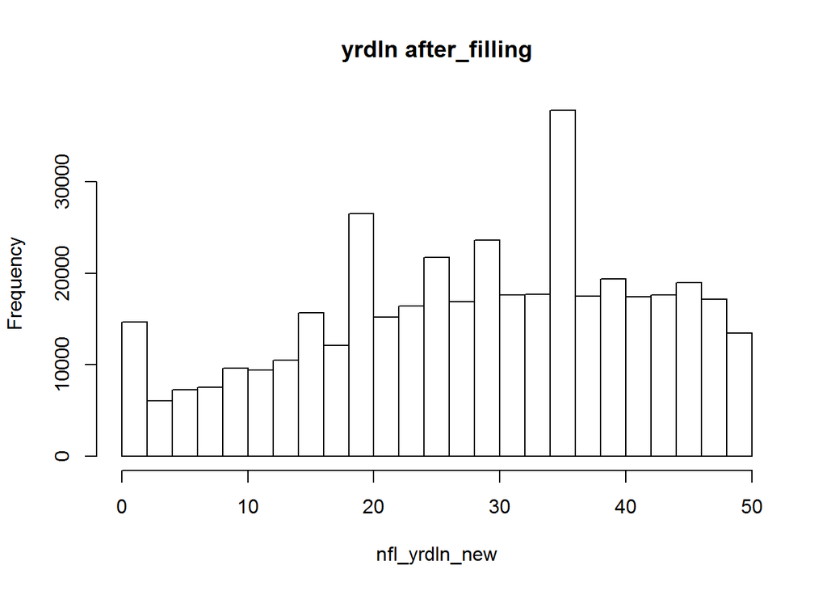

```r
nfl_yrdln_new<-nfl_total[["yrdln"]]
temp=density(na.omit(nfl_total[["yrdln"]]),bw=0.5)
nfl_yrdln_new[which(is.na(nfl_yrdln_new))]<-round(temp$x[which.max(temp$y)])
hist(nfl_yrdln_new,main="yrdln after_filling")
```

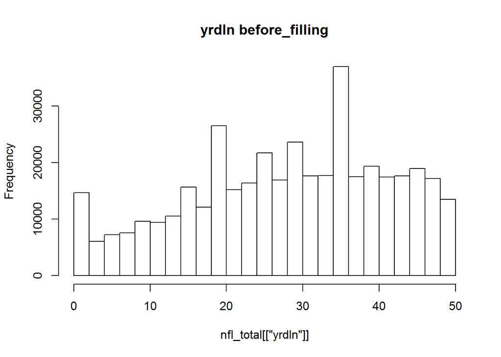

```r
hist(nfl_total[["yrdln"]],main="yrdln before_filling")
```

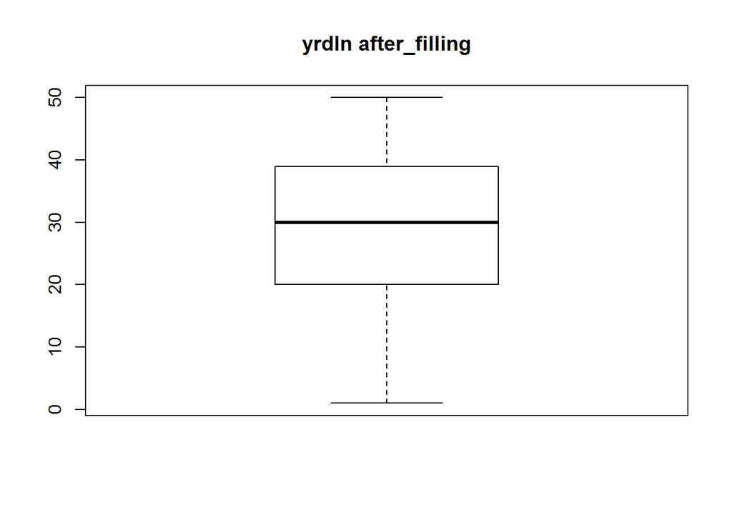

```r
boxplot(nfl_yrdln_new,main="yrdln after_filling")
```

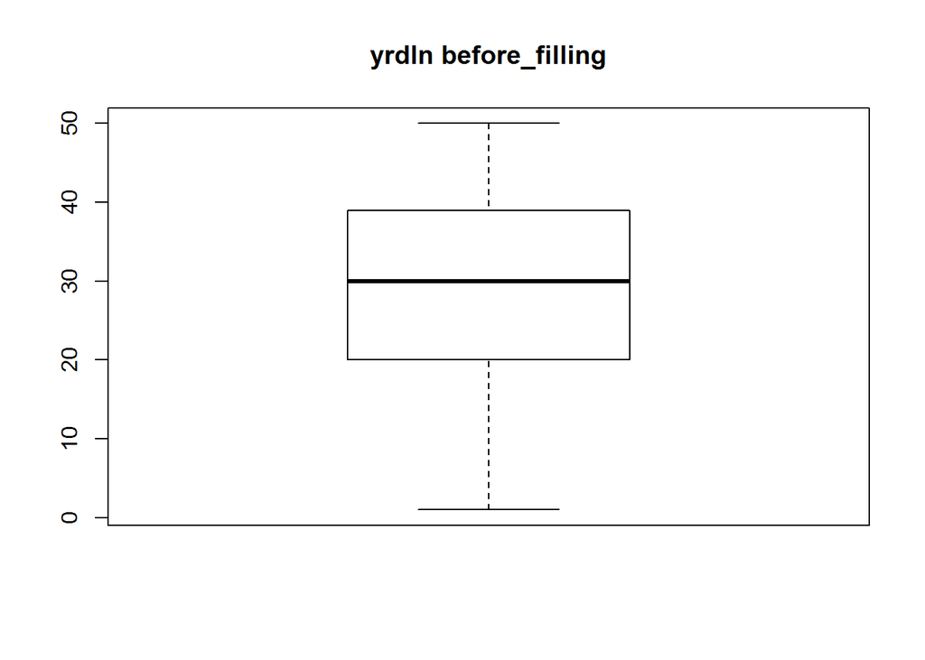

```r
boxplot(nfl_total[["yrdln"]],main="yrdln before_filling")
```

PlayTimeDiff

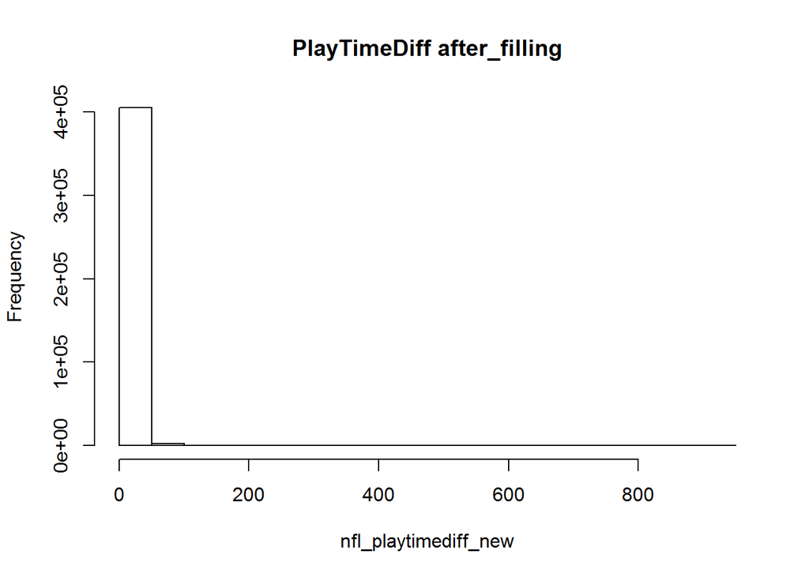

```r
nfl_playtimediff_new<-nfl_total[["PlayTimeDiff"]]
temp=density(na.omit(nfl_total[["PlayTimeDiff"]]),bw=0.5)
nfl_playtimediff_new[which(is.na(nfl_playtimediff_new))]<-round(temp$x[which.max(temp$y)])
hist(nfl_playtimediff_new,main="PlayTimeDiff after_filling")
```

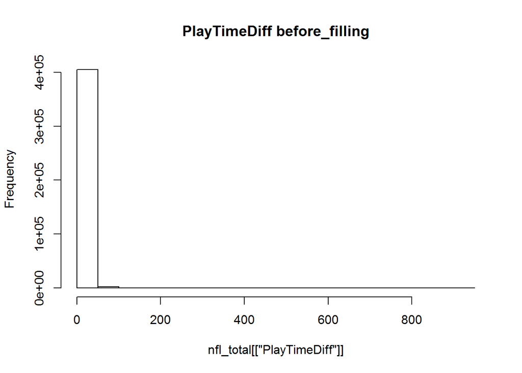

```r
hist(nfl_total[["PlayTimeDiff"]],main="PlayTimeDiff before_filling")
```

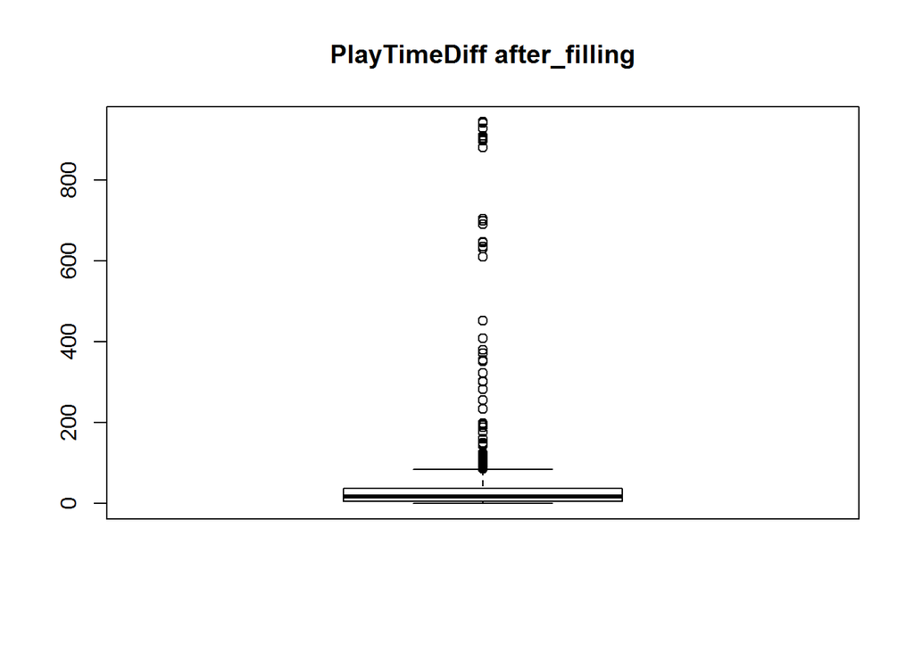

```r
boxplot(nfl_playtimediff_new,main="PlayTimeDiff after_filling")
```

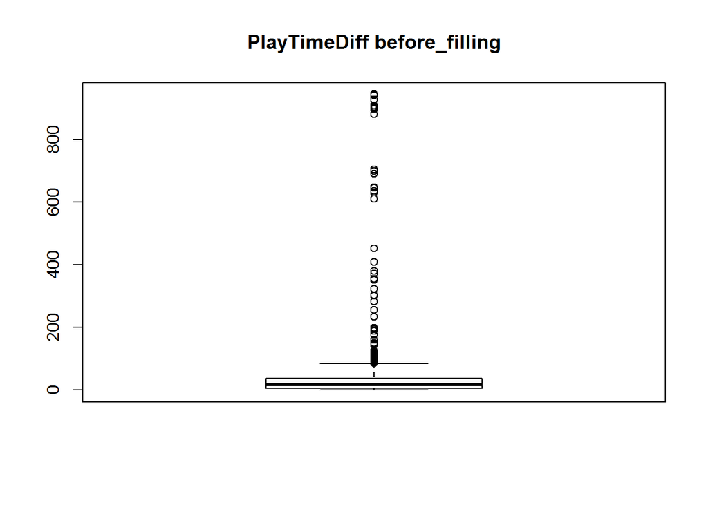

```r
boxplot(nfl_total[["PlayTimeDiff"]],main="PlayTimeDiff before_filling")
```

yrdline100

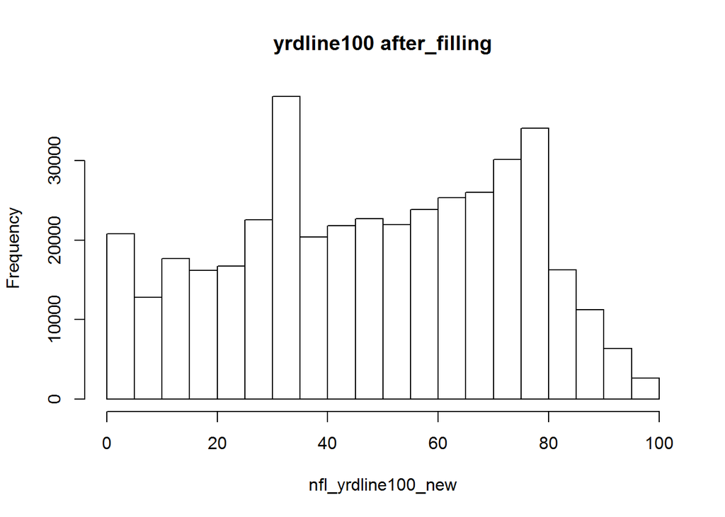

```r
nfl_yrdline100_new<-nfl_total[["yrdline100"]]
temp=density(na.omit(nfl_total[["yrdline100"]]),bw=0.5)
nfl_yrdline100_new[which(is.na(nfl_yrdline100_new))]<-round(temp$x[which.max(temp$y)])
hist(nfl_yrdline100_new,main="yrdline100 after_filling")
```

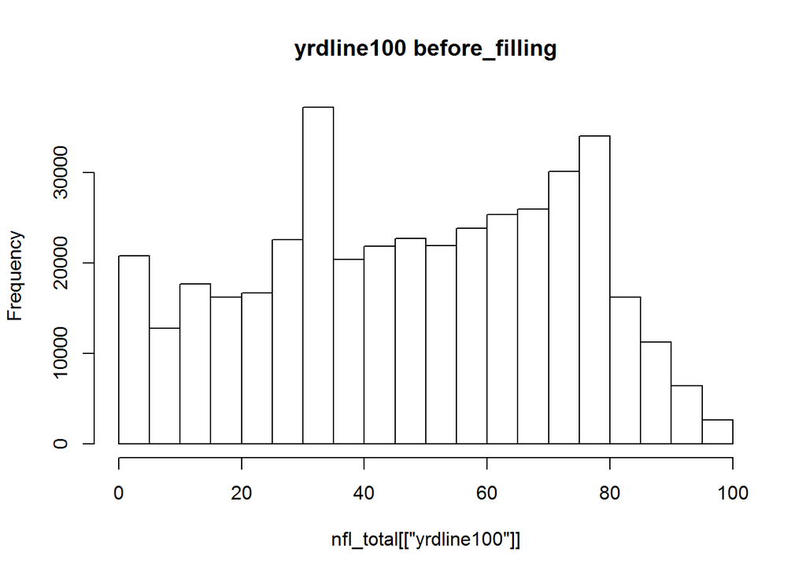

```r
hist(nfl_total[["yrdline100"]],main="yrdline100 before_filling")
```

[figure not shown]

```r
boxplot(nfl_playtimediff_new,main="yrdline100 after_filling")
```

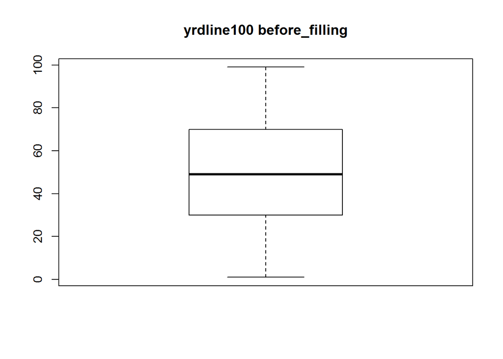

```r
boxplot(nfl_total[["yrdline100"]],main="yrdline100 before_filling")
```

FieldGoalDistance

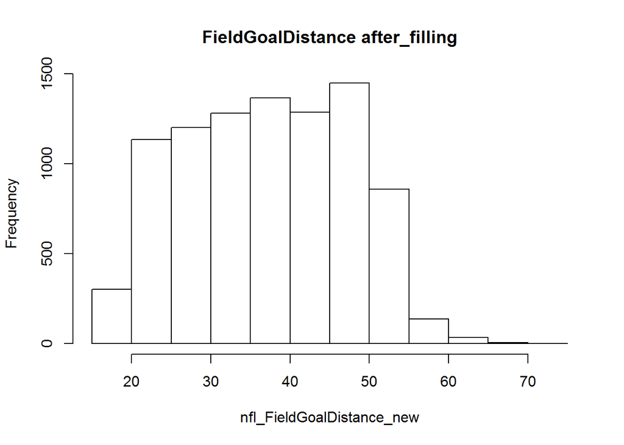

```r
nfl_FieldGoalDistance_new<-nfl_total[["FieldGoalDistance"]]
temp=density(na.omit(nfl_total[["FieldGoalDistance"]]),bw=0.5)
nfl_FieldGoalDistance_new[which(is.na(nfl_FieldGoalDistance_new) & nfl_total[["FieldGoalResult"]]=="Good")]<-round(temp$x[which.max(temp$y)])
hist(nfl_FieldGoalDistance_new,main="FieldGoalDistance after_filling")
```

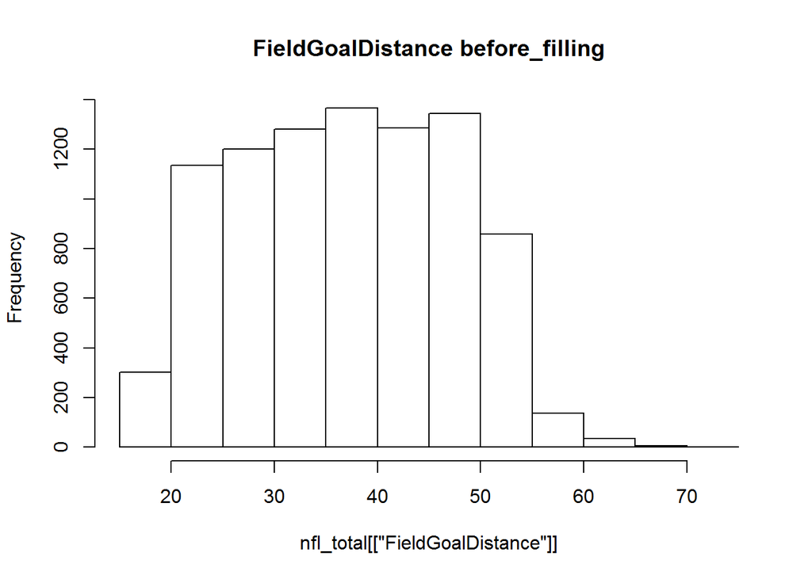

```r
hist(nfl_total[["FieldGoalDistance"]],main="FieldGoalDistance before_filling")
```

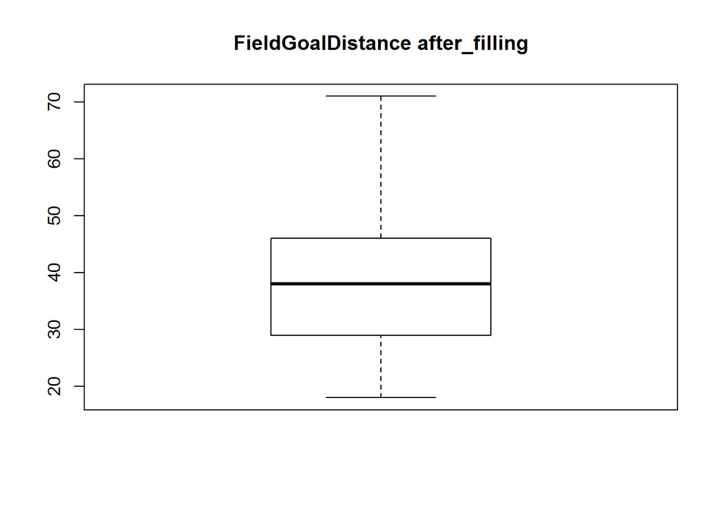

```r
boxplot(nfl_FieldGoalDistance_new,main="FieldGoalDistance after_filling")
```

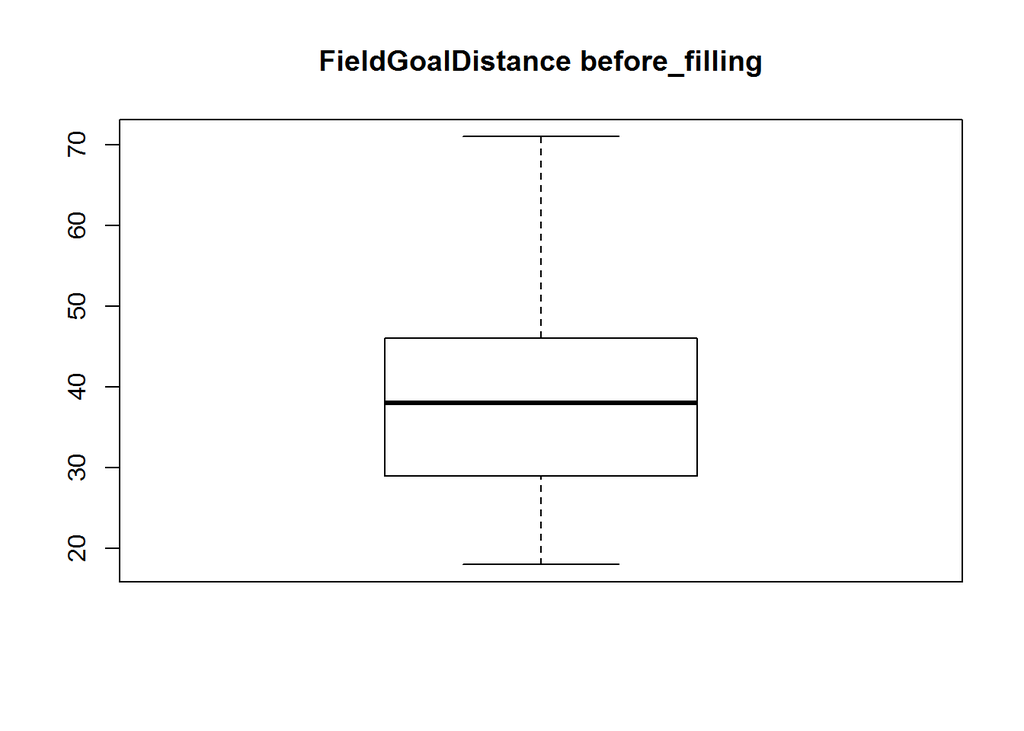

```r
boxplot(nfl_total[["FieldGoalDistance"]],main="FieldGoalDistance before_filling")
```

ScoreDiff

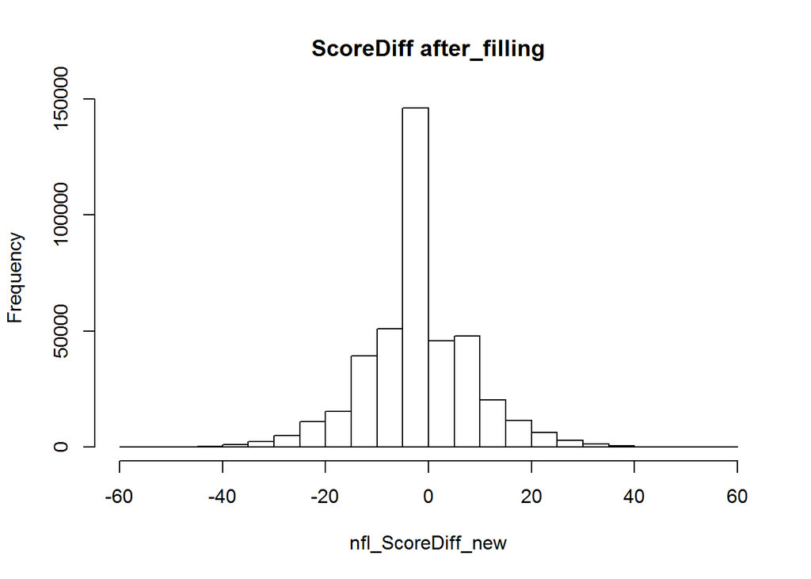

```r
nfl_ScoreDiff_new<-nfl_total[["ScoreDiff"]]
temp=density(na.omit(nfl_total[["ScoreDiff"]]),bw=0.5)
nfl_ScoreDiff_new[which(is.na(nfl_ScoreDiff_new))]<-round(temp$x[which.max(temp$y)])
hist(nfl_ScoreDiff_new,main="ScoreDiff after_filling")
```

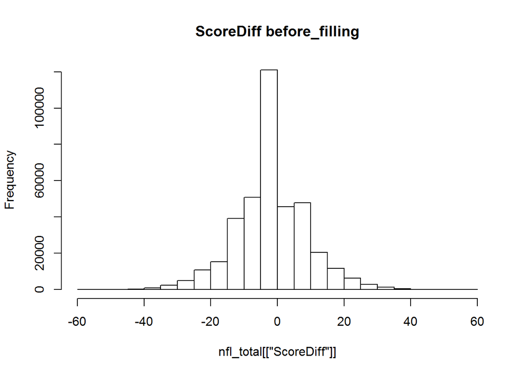

```r
hist(nfl_total[["ScoreDiff"]],main="ScoreDiff before_filling")
```

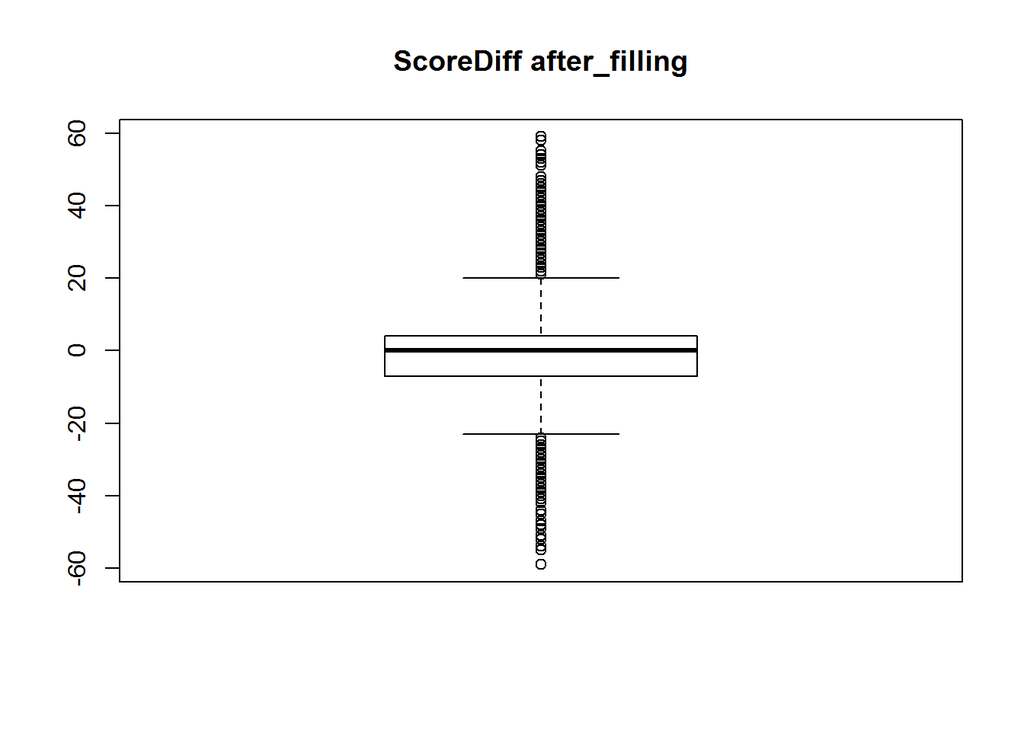

```r
boxplot(nfl_ScoreDiff_new,main="ScoreDiff after_filling")
```

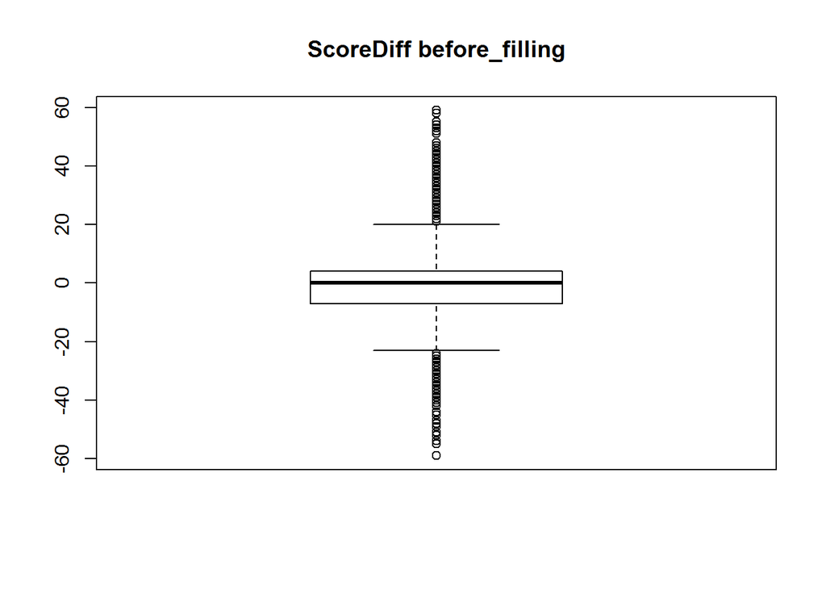

```r
boxplot(nfl_total[["ScoreDiff"]],main="ScoreDiff before_filling")
```

Before beginning some “advanced” missing-value-handling method, we must have a closer look at the NA values.

According to the NA pattern analysis above, the major part of NA come from these attributed: yrdln(840), PlayTimeDiff(444), yrdline100(840), FieldGoalDistance(398740), ScoreDiff(24988).

Some correlation exploration might help to better understand them.

```r
symnum(cor(nfl_numeric[,1:11],use="complete.obs"))
```

```
##                   yr ydst ydsn A YA PT y1 Y. F P. S
## yrdln             1
## ydstogo           .  1
## ydsnet            .       1
## AirYards          ?  ?    ?    1
## YardsAfterCatch   ?  ?    ?    ? 1
## PlayTimeDiff                   ? ?  1
## yrdline100        B  .    .    ? ?     1
## Yards.Gained                   ? ?        1
## FieldGoalDistance B  .    .    ? ?     B     1
## Penalty.Yards                  ? ?             1
## ScoreDiff                      ? ?                1
## attr(,"legend")
## [1] 0 ' ' 0.3 '.' 0.6 ',' 0.8 '+' 0.9 '*' 0.95 'B' 1 \t    ## NA: '?'
```

From the matrix above, it’s obvious that “yrdln” and “yrdline100” is exactly the same. Take a look of the PlayType of these yard_missing plays.

```r
count(nfl_total[which(is.na(nfl_total[["yrdln"]])),]["PlayType"])
```

```
##             PlayType freq
## 1        End of Game   84
## 2           Half End    1
## 3        Quarter End  196
## 4                Run    7
## 5            Timeout  498
## 6 Two Minute Warning   54
```

It’s obvious that these plays did not end normally. And this can be conformed by analyzing the attribute “down” of them.

```r
count(nfl_total[which(is.na(nfl_total[["yrdln"]])),]["down"])
```

```
##   down freq
## 1   NA  840
```

Usually a play needed to be ended with a down. So it can be sure that the “yrlin” and “yrdline100” missing values have never existed and there is no need to fill them.

Next, we look at NA in “PlayTimeDiff”.

```r
playtimediff_na<-nfl_total[which(is.na(nfl_total[["PlayTimeDiff"]])),]
count(playtimediff_na[["PlayType"]])
```

```
##                     x freq
## 1         End of Game  110
## 2         Extra Point    2
## 3            Half End   39
## 4             No Play    4
## 5                Pass    8
## 6         Quarter End  238
## 7                 Run   37
## 8                Sack    1
## 9             Timeout    4
## 10 Two Minute Warning    1
```

From the counting result above it’s easy to notice that these plays did not end normally. Since the number of NA in “PlayTimeDiff” is relatively small, I can check the “desc” of everyone of them and make sure all 444 plays did not end in a usually way. So, there is also no need to deal with these 444 NA in “PlayTimeDiff”.

When it comes to NA in “ScoreDiff”, it’s reasonably to check if there was any new score in those plays.

```r
count(nfl_total[which(is.na(nfl_total[["ScoreDiff"]])),][["sp"]])
```

```
##   x  freq
## 1 0 24988
```

It’s obvious the “ScoreDiff” of those plays are the same of the play just happened ahead of them since no new score was gain in those plays.

The following script can fill those NA with the “ScoreDiff” value of the play just ahead of them.

```r
scorediff_new<-nfl_total[["ScoreDiff"]]
scorediff_new[which(is.na(scorediff_new))]<-nfl_total[(which(is.na(scorediff_new))-1),"ScoreDiff"]

count(is.na(scorediff_new))
```

```
##       x   freq
## 1 FALSE 407215
## 2  TRUE    473
```

Still there are 473 NA values so we do it one more time.

```r
scorediff_new[which(is.na(scorediff_new))]<-nfl_total[(which(is.na(nfl_total[["ScoreDiff"]]))-1),"ScoreDiff"]
count(is.na(scorediff_new))
```

```
##       x   freq
## 1 FALSE 407678
## 2  TRUE     10
```

And again.

```r
scorediff_new[which(is.na(scorediff_new))]<-nfl_total[(which(is.na(nfl_total[["ScoreDiff"]]))-1),"ScoreDiff"]
count(is.na(scorediff_new))
```

```
##       x   freq
## 1 FALSE 407688
```

Now the NA in “ScoreDiff” are handled properly. Visualize it.

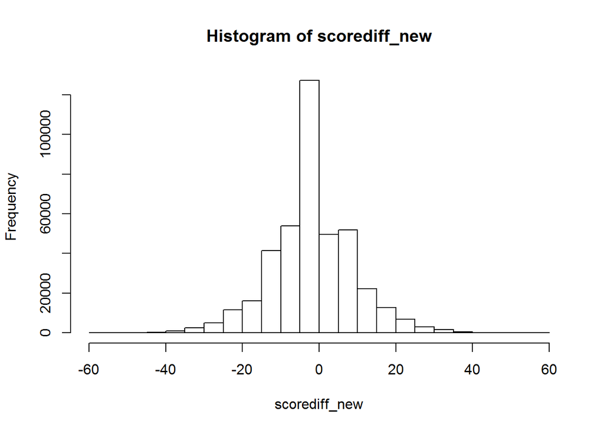

```r
hist(scorediff_new)
```

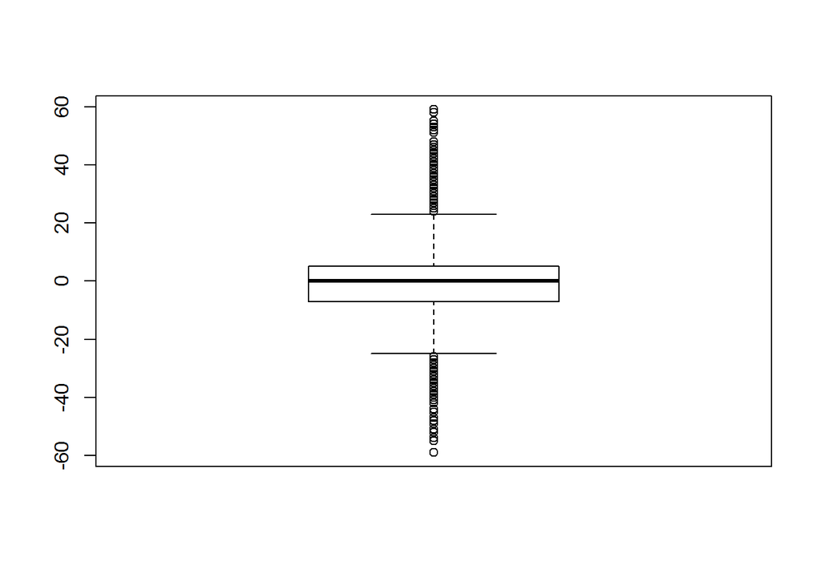

```r
boxplot(scorediff_new)
```

```r
summary(scorediff_new)
```

```
##    Min. 1st Qu.  Median    Mean 3rd Qu.    Max.
## -59.000  -7.000   0.000  -1.091   5.000  59.000
```

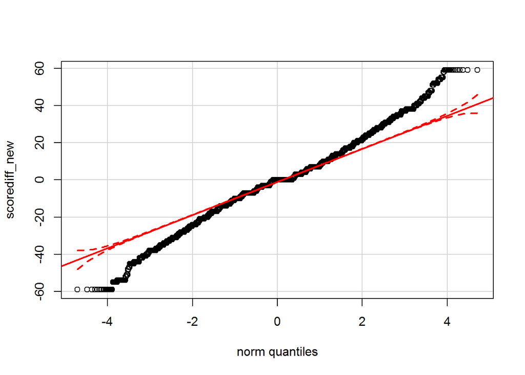

```r
qqPlot(scorediff_new)
```

Finally, we start analyzing the NA in “FieldGoalDistance”. Since there is an attribute named “FieldGoalResult” indicating the result of every field goal, it’s better to have it checked before filling NA values.

```r
 count(nfl_total[which(is.na(nfl_total[["FieldGoalDistance"]])),]["FieldGoalResult"])
```

```
##   FieldGoalResult   freq
## 1         Blocked      8
## 2            Good    103
## 3            <NA> 398629
```

A NA in “FieldGoalResult” means that there did not exist any goal.

In addition, 8 goals were blocked.

So just 103 good goals without a distance value need to be filled.

Here two methods are used.

The first method use the correlation between “yrdln” and “FieldGoalDistance”.

As it’s shown in the correlation matrix, there is strong linear relationship between them .

A linear model is settled to fit them.

```r
lm(FieldGoalDistance~yrdln, data=nfl_numeric)
```

```
##
## Call:
## lm(formula = FieldGoalDistance ~ yrdln, data = nfl_numeric)
##
## Coefficients:
## (Intercept)        yrdln
##     18.0286       0.9998
```

FieldGoalDistance=0.9998*yrdln+18.0286

```r
fieldgoaldistance_new<-nfl_numeric[["FieldGoalDistance"]]
fieldgoaldistance_need_fill<-which(is.na(nfl_total["FieldGoalDistance"]) & nfl_total[["FieldGoalResult"]]=="Good")
fieldgoaldistance_new[fieldgoaldistance_need_fill]<-0.9998*nfl_numeric[fieldgoaldistance_need_fill,"yrdln"]+18.0286
count(is.na(fieldgoaldistance_new))
```

```
##       x   freq
## 1 FALSE   9051
## 2  TRUE 398637
```

398740-398637=103 Exactly the 103 good goal NA values are filled. Visualize it.

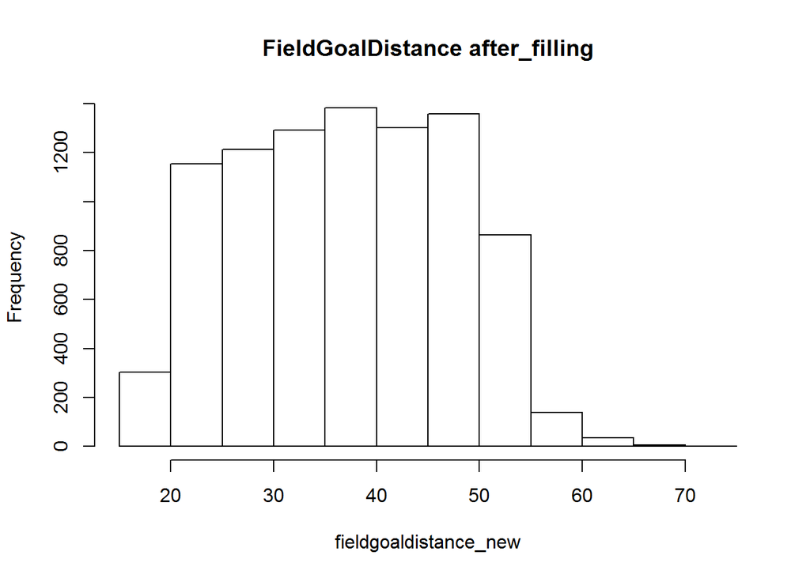

```r
hist(fieldgoaldistance_new,main = "FieldGoalDistance after_filling")
```

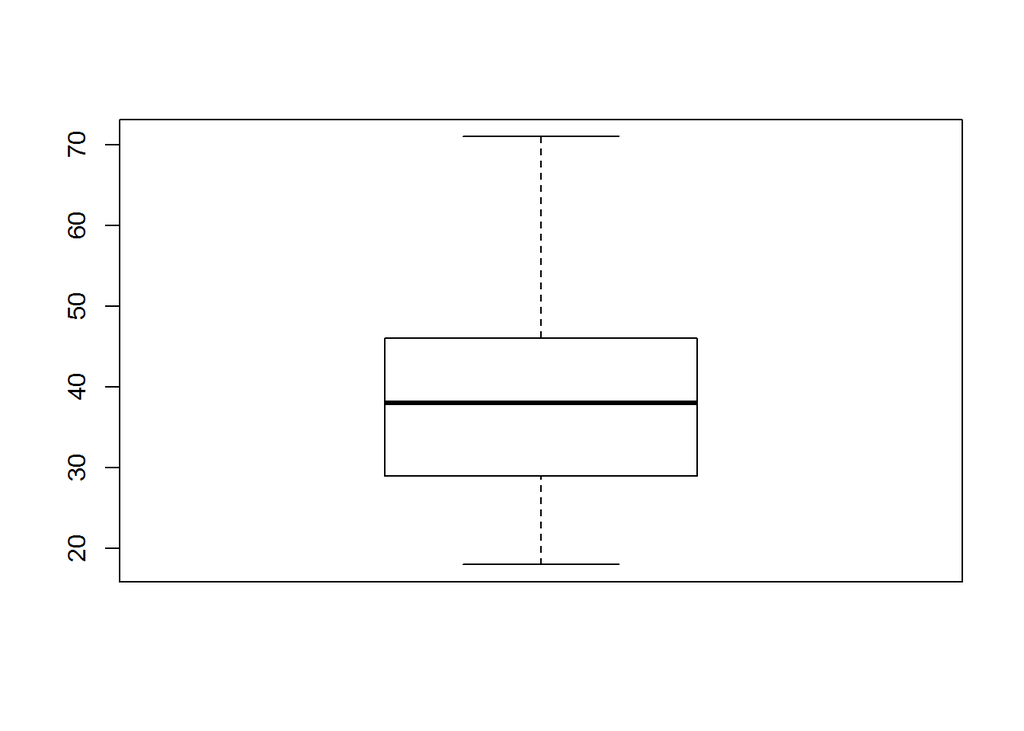

```r
boxplot(fieldgoaldistance_new)
```

```r
summary(fieldgoaldistance_new)
```

```
##    Min. 1st Qu.  Median    Mean 3rd Qu.    Max.    NA's
##    18.0    29.0    38.0    37.4    46.0    71.0  398637
```

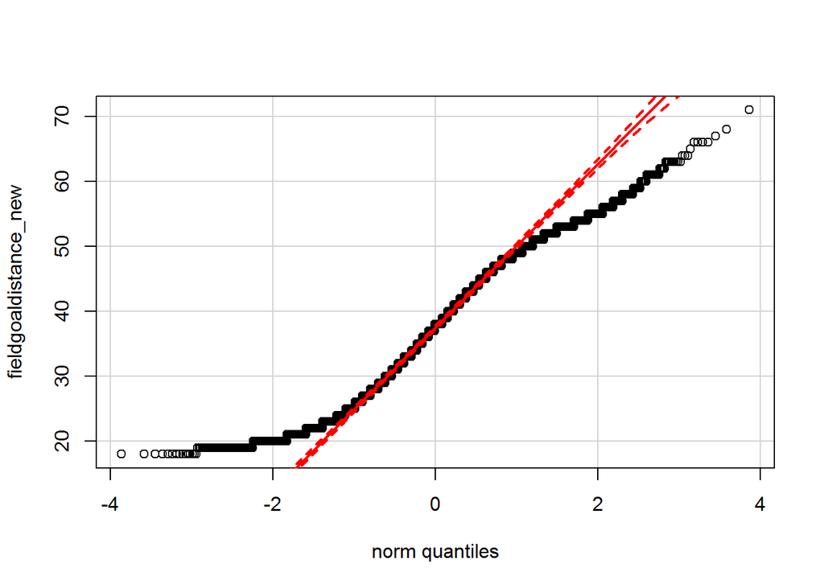

```r
qqPlot(fieldgoaldistance_new)
```

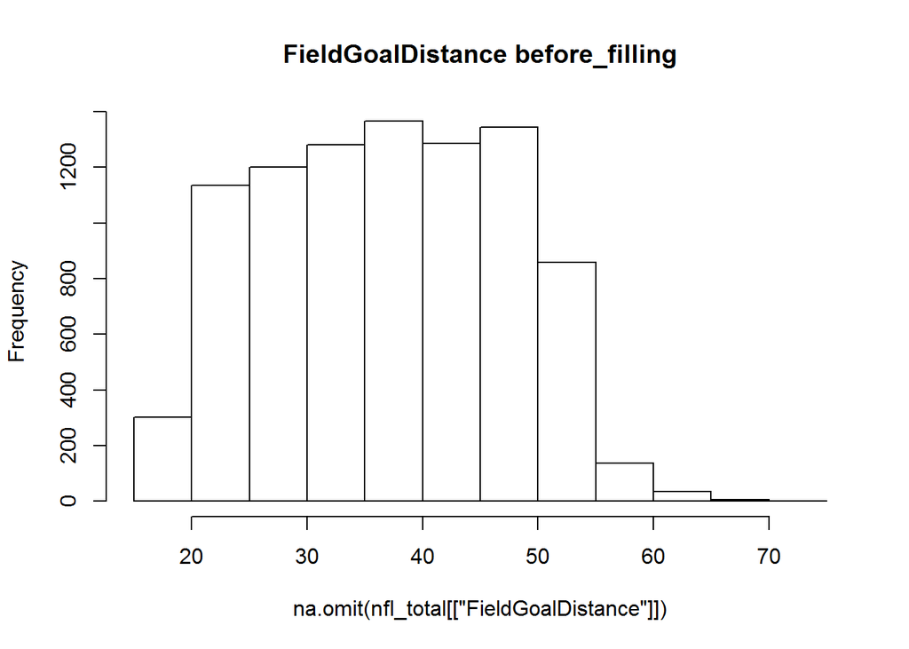

```r
hist(na.omit(nfl_total[["FieldGoalDistance"]]),main = "FieldGoalDistance before_filling")
```

```r
fieldgoaldistance_good<-nfl_total[which(nfl_total[["FieldGoalResult"]]=="Good"),]
temp=density(na.omit(fieldgoaldistance_good[["FieldGoalDistance"]]),bw=0.5)
fieldgoaldistance_new2<-nfl_numeric[["FieldGoalDistance"]]
fieldgoaldistance_new2[fieldgoaldistance_need_fill]<-temp$x[which.max(temp$y)]
```

Visualize it.

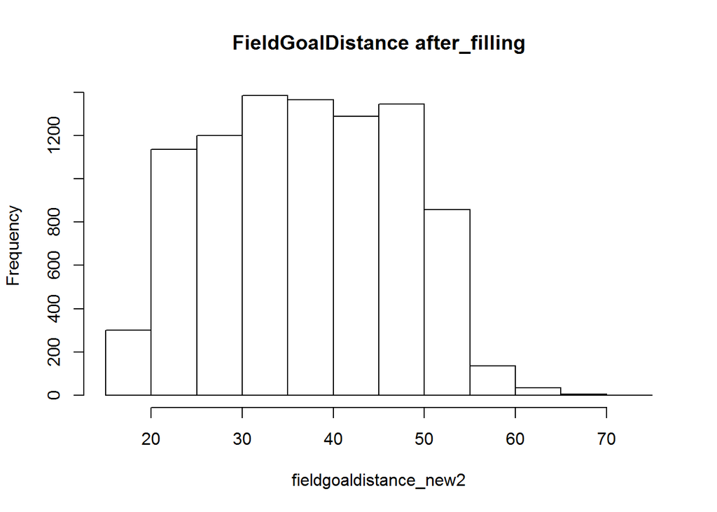

```r
hist(fieldgoaldistance_new2,main = "FieldGoalDistance after_filling")
```

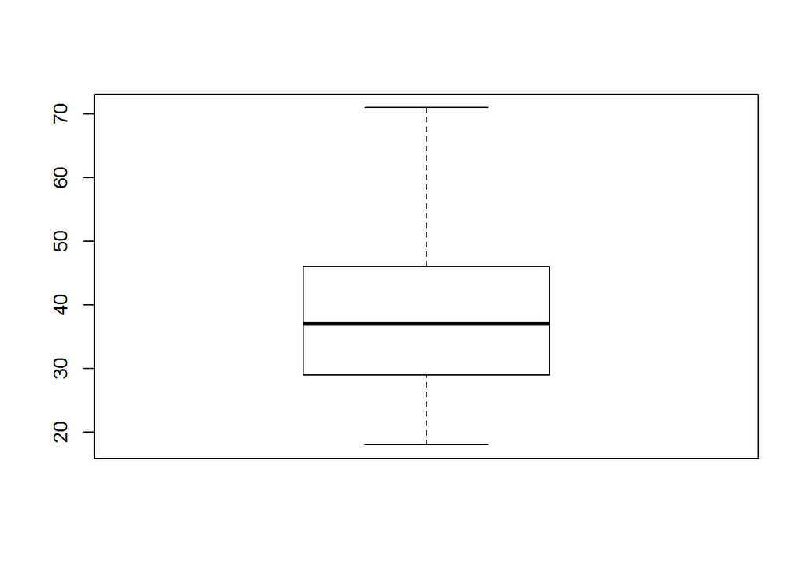

```r
boxplot(fieldgoaldistance_new2)
```

```r
summary(fieldgoaldistance_new2)
```

```
##    Min. 1st Qu.  Median    Mean 3rd Qu.    Max.    NA's
##    18.0    29.0    37.0    37.4    46.0    71.0  398637
```

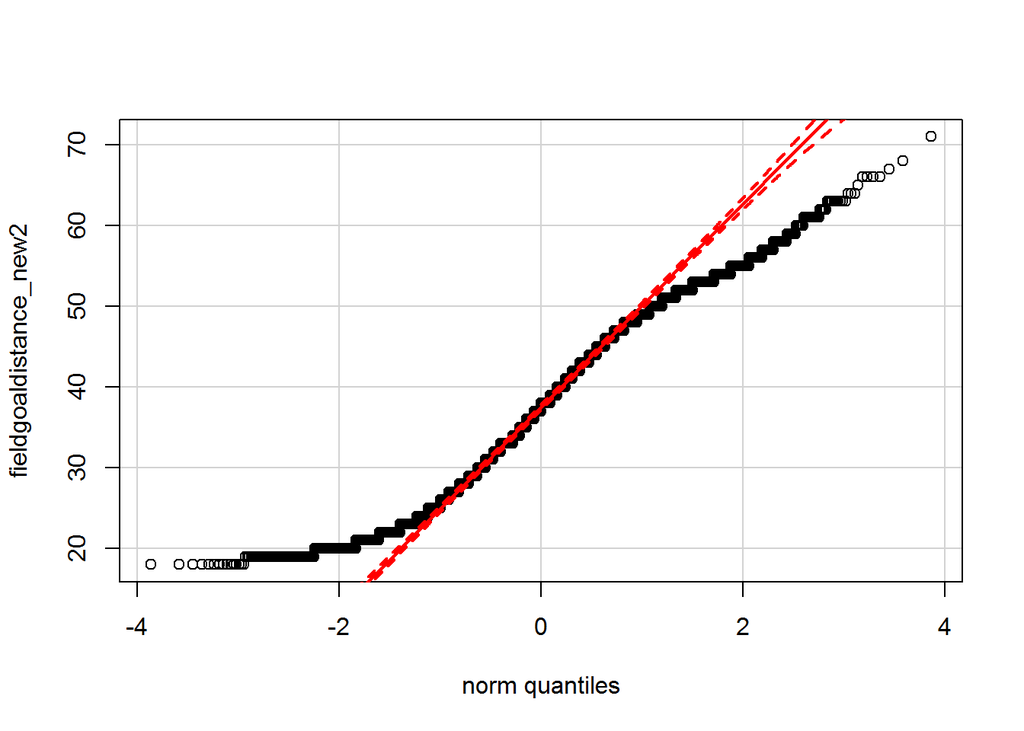

```r
qqPlot(fieldgoaldistance_new2)
```

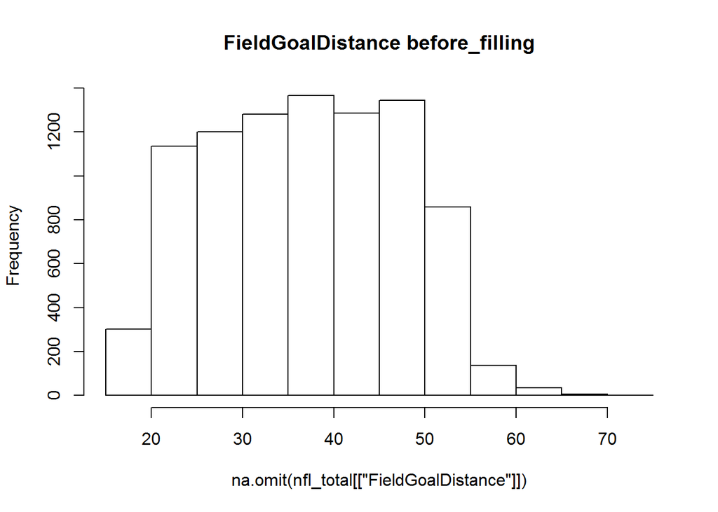

```r
hist(na.omit(nfl_total[["FieldGoalDistance"]]),main = "FieldGoalDistance before_filling")
```